# R Notebook

## Day 3 - homework review - recap Manual Model Development

```r
library(tidyverse)
library(fastDummies)
library(mosaicData)
library(tidyverse)
library(janitor)
library(GGally)
library(ggfortify)
library(mosaic)
library(skimr)
```

Step by step model building:

- First question: What does 1 row represent? -> Here, a house (great, because we like granular version of data (single representation)) -> So we are making a model for the average individual house price
- Acquaint ourselves: What do the variables represent? -> pipe skim output in view(), to see each variable per row -> numerical data is generally positive skewed (right skewed) -> A positive skewed numerical variable is difficult to add as predictor (or describing best the extreme values at right or left) This is where **Feature engineering** comes in here. - For example by doing log transformation (making a right skewed, log normal) You squeeze the extreme values to a more normal distribution.

*Feature Engineering*: taking raw materials making more useful.

- Part of this is also, how to make your data more representative?
- So for example a log transformation for rightskewed data. (transforms the x axes into set multiplied steps)

-> So you see rightskewed variables, (e.g. currency, count data) -> and you just immediately log transform it.

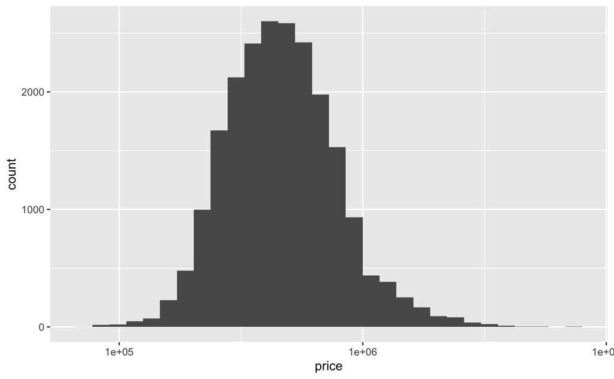

```r
houses <- read_csv("data/kc_house_data.csv")
# e.g. for price:

houses %>%
  ggplot(aes(x = price)) +
  geom_histogram() +
scale_x_continuous(trans = "log10")
```

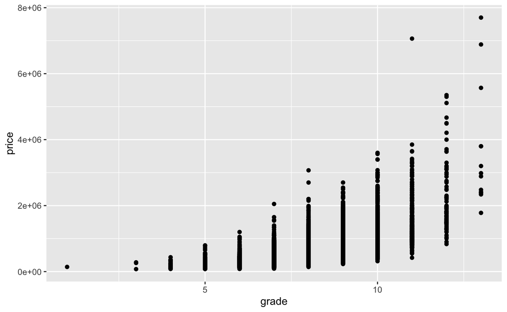

```r
houses_logged <- houses %>%
  mutate(ln_house_price = log(price))

# e.g. for grade:
# grade is now numerical, but we have too little information to assume
# that grade 10 is twice as good as 5.

houses %>%
  ggplot(aes(x = grade, y = price)) +
  geom_point()
```

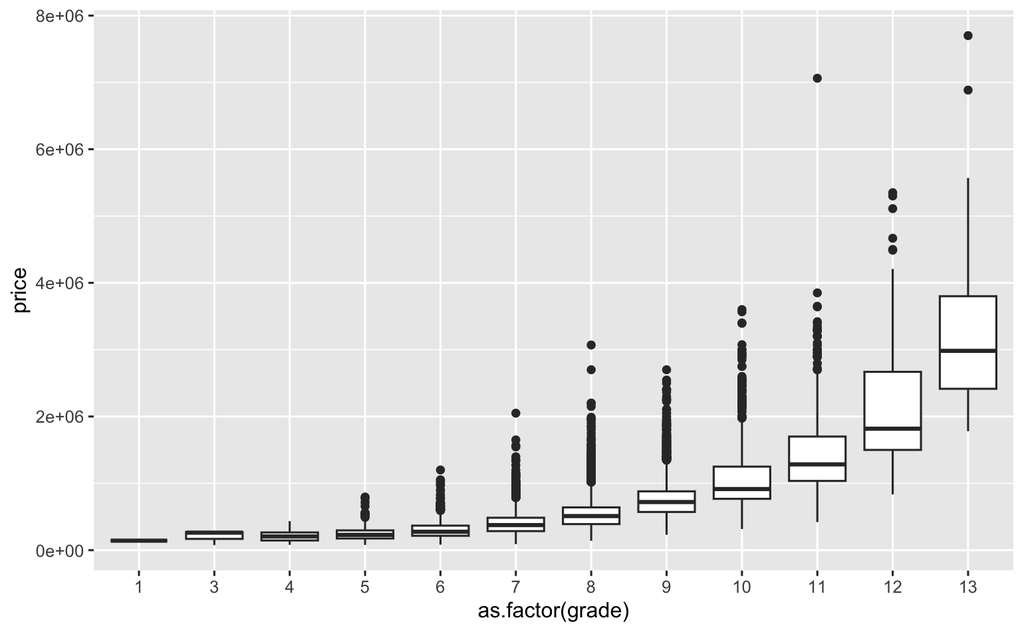

```r
# If we treat it as a categoric, we than give the model one grade "as one arm"
# You model than gets a separate coefficient for every category (= every grade)
# which is good, because each grade represents something else, a different grade.
houses %>%
  ggplot(aes(x = as.factor(grade), y = price)) +
  geom_boxplot()
```

Based on this plot, we could also conclude that grade 1-6 are very similar in result, so we could decide to combine. - But we like to get more information first, e.g. google grade - also check the summary stats of your model, when all grade variables are included individually do we see a significant impact?

-> There is some critique on step-by-step regression model making - it might be that the effects are actually false effect you are seeing. - might be best to start somewhere in the middle and have best predictors added at once - and than see if you want to include more.

```r
summary(lm())
```

```
Error in h(simpleError(msg, call)) :
  error in evaluating the argument 'object' in selecting a method for function 'summary': argument is not a valid model
```

```r
houses_tidy <- houses %>%
  select(-c("id", "date", "sqft_living15", "sqft_lot15", "zipcode")) %>%
  mutate(waterfront = as.logical(waterfront)) #%>%
```

```
Error in select(., -c("id", "date", "sqft_living15", "sqft_lot15", "zipcode")) :
  unused argument (-c("id", "date", "sqft_living15", "sqft_lot15", "zipcode"))
```

```r
#splitting data in numeric and non-numeric
houses_tidy_numeric <- houses_tidy %>%
  select_if(is.numeric)

houses_tidy_nonnumeric <- houses_tidy %>%
  select_if(function(x) !is.numeric(x))

houses_tidy_nonnumeric$price <- houses_tidy$price
```

Making ggpairs easier to work with: - subset (only selecting few columns) - silence text output - ggsave it

- use ggsave() , you will save the most recent plot e.g. (“ggpairs_num.png”)

Let’s built the model

```r
model <- lm(price ~ sqft_above, houses_tidy)
model_2 <- lm(price ~ sqft_above + grade, houses_tidy)

summary(model)
```

```
Call:
lm(formula = price ~ sqft_above, data = houses_tidy)

Residuals:
    Min      1Q  Median      3Q     Max
-913132 -165624  -41468  109327 5339232

Coefficients:
            Estimate Std. Error t value Pr(>|t|)
(Intercept)  59953.2     4729.8   12.68   <2e-16 ***
sqft_above     268.5        2.4  111.87   <2e-16 ***
---
Signif. codes:  0 ‘***’ 0.001 ‘**’ 0.01 ‘*’ 0.05 ‘.’ 0.1 ‘ ’ 1

Residual standard error: 292200 on 21611 degrees of freedom
Multiple R-squared:  0.3667,    Adjusted R-squared:  0.3667
F-statistic: 1.251e+04 on 1 and 21611 DF,  p-value: < 2.2e-16
```

```r
summary(model_2)
```

```
Call:
lm(formula = price ~ sqft_above + grade, data = houses_tidy)

Residuals:
     Min       1Q   Median       3Q      Max
-1845587  -136387   -34657    89917  5291001

Coefficients:
             Estimate Std. Error t value Pr(>|t|)
(Intercept) 1.212e+05  2.517e+05   0.482   0.6301
sqft_above  7.177e+01  3.244e+00  22.123  < 2e-16 ***
grade3      4.166e+04  2.906e+05   0.143   0.8860
grade4      4.629e+04  2.560e+05   0.181   0.8565
grade5      5.954e+04  2.522e+05   0.236   0.8134
grade6      1.040e+05  2.517e+05   0.413   0.6794
grade7      1.803e+05  2.517e+05   0.716   0.4738
grade8      2.876e+05  2.517e+05   1.143   0.2532
grade9      4.690e+05  2.518e+05   1.862   0.0626 .
grade10     7.272e+05  2.519e+05   2.886   0.0039 **
grade11     1.099e+06  2.522e+05   4.357 1.32e-05 ***
grade12     1.736e+06  2.535e+05   6.851 7.55e-12 ***
grade13     3.153e+06  2.618e+05  12.043  < 2e-16 ***
---
Signif. codes:  0 ‘***’ 0.001 ‘**’ 0.01 ‘*’ 0.05 ‘.’ 0.1 ‘ ’ 1

Residual standard error: 251700 on 21600 degrees of freedom
Multiple R-squared:  0.5303,    Adjusted R-squared:  0.5301
F-statistic:  2033 on 12 and 21600 DF,  p-value: < 2.2e-16
```

-> WHat to do with the data if not all categoric categories are turning out to be significant. 1 - e.g. see if grouping does make sense (group those categories that are non significnat) -> however! These groups need to be justifiable to group, e.g. don’t group high with low.. Grouping needs to make SENSE! 2 - NEVER JUST IGNORE THE NON SIGNIFICNAT and keep using the numbers from the entire model 3 - do ANOVA test: e.g. test if adding categorie does help in creating better model Can we justify adding all categories of grade? -> its all or none for the ANOVA

```r
anova(model, model_2)
```

```
Analysis of Variance Table

Model 1: price ~ sqft_above
Model 2: price ~ sqft_above + grade
  Res.Df        RSS Df  Sum of Sq      F    Pr(>F)
1  21611 1.8447e+15
2  21600 1.3681e+15 11 4.7663e+14 684.11 < 2.2e-16 ***
---
Signif. codes:  0 ‘***’ 0.001 ‘**’ 0.01 ‘*’ 0.05 ‘.’ 0.1 ‘ ’ 1
```

-> So we see p-value being significant. And this means that we have evidence that model is better when all categories are added. We add grade.

```r
houses_tidy <- houses_tidy %>%
  mutate(grade_grouped = as.factor(if_else(as.numeric(grade) < 8, 7, as.numeric(grade))))
```

[output not shown]

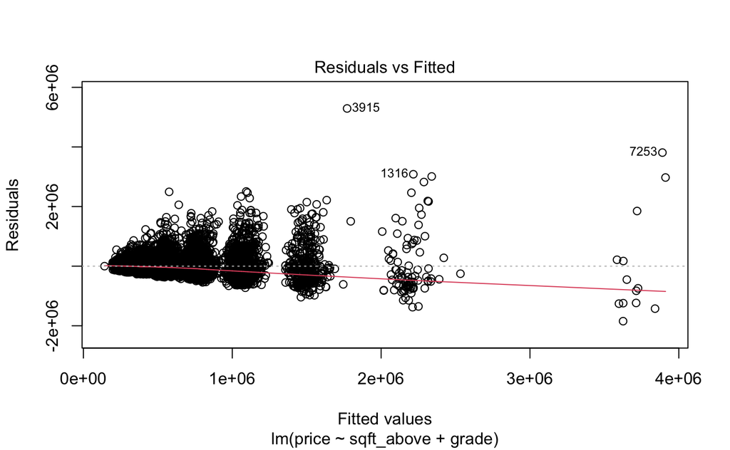

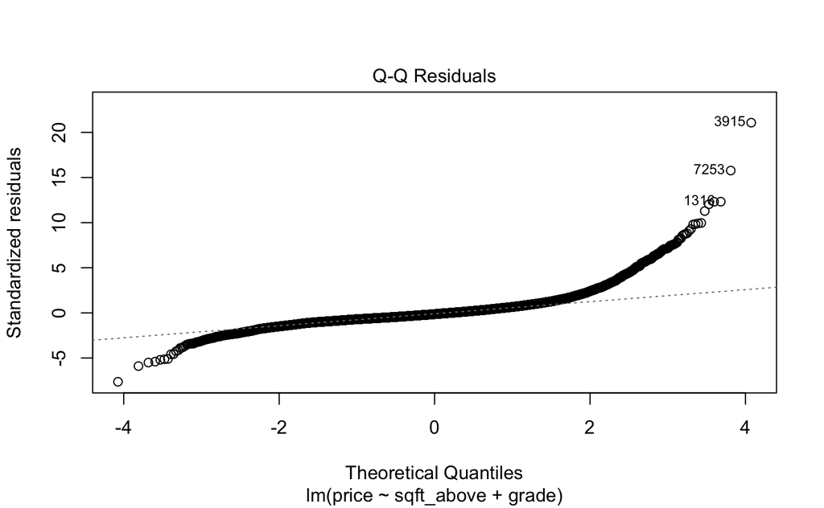

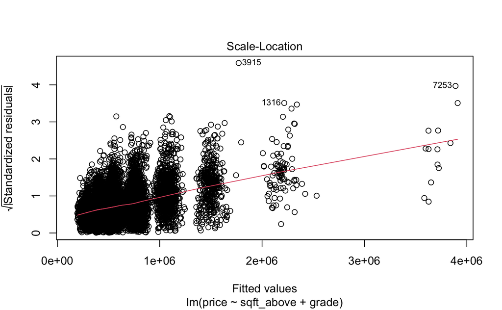

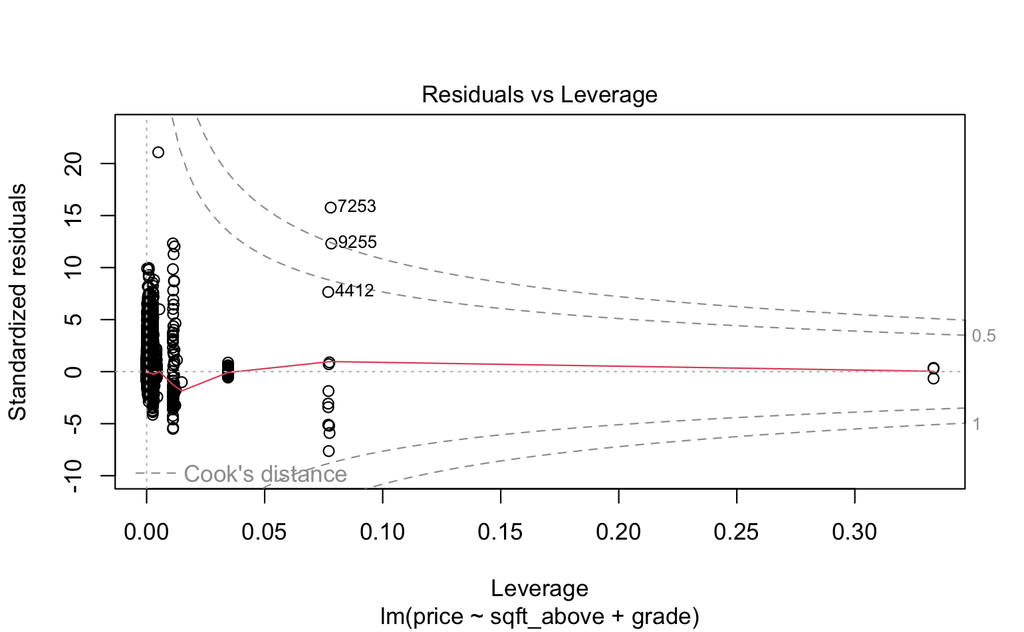

```r
plot(model_2)
```

-> First plot shows (pattern presence in residuals) that each point is a residual, this is how “wrong” we are. - the plot shows a pattern, there are clumps of points representing the grades. reason why data is still somewhat scattered is due to influence of sqft_above

- we also see a cone shape: this indicates that we underpredict prices for low house prices and overpredict prices for high houseprices -> this could be due to the fact that we did not do a log transformation on price. it makes it more difficult to predict the prices of the more extreme sides.

This is not OK, we see a strong pattern here

-> third plot, here all residuals are all made positive. - main question here: by our guess how wrong are we? - we see heteroscedacity. We want homoscedacity: we want to be equally wrong throughout the data - we see here that we increasinly get more wrong towards higher house prices.

It is very difficult to say, this is the pooint that it is wrong. -> it is an indication to improve the model, based on comapring the graphs. -> think what the models say to help understand it better.

```r
library(modelr)
```

How to see the residuals:

| price | bedrooms | bathrooms | sqft_living | sqft_lot | floors | waterfront | view | condition | grade | sqft_above | sqft_basement | yr_built | lat | long | renovated | resid |
| --- | --- | --- | --- | --- | --- | --- | --- | --- | --- | --- | --- | --- | --- | --- | --- | --- |
| 221900 | 3 | 1.00 | 1180 | 5650 | 1.0 | FALSE | 0 | 3 | 7 | 1180 | 0 | 1955 | 47.5112 | -122.257 | FALSE | -164288.2766 |
| 538000 | 3 | 2.25 | 2570 | 7242 | 2.0 | FALSE | 0 | 3 | 7 | 2170 | 400 | 1951 | 47.7210 | -122.319 | TRUE | 80757.6081 |
| 180000 | 2 | 1.00 | 770 | 10000 | 1.0 | FALSE | 0 | 3 | 6 | 770 | 0 | 1933 | 47.7379 | -122.233 | FALSE | -100485.1448 |
| 604000 | 4 | 3.00 | 1960 | 5000 | 1.0 | FALSE | 0 | 5 | 7 | 1050 | 910 | 1965 | 47.5208 | -122.393 | FALSE | 227142.0618 |
| 510000 | 3 | 2.00 | 1680 | 8080 | 1.0 | FALSE | 0 | 3 | 8 | 1680 | 0 | 1987 | 47.6168 | -122.045 | FALSE | -19401.8866 |
| 1225000 | 4 | 4.50 | 5420 | 101930 | 1.0 | FALSE | 0 | 3 | 11 | 3890 | 1530 | 2001 | 47.6561 | -122.005 | FALSE | -274484.1535 |
| 257500 | 3 | 2.25 | 1715 | 6819 | 2.0 | FALSE | 0 | 3 | 7 | 1715 | 0 | 1995 | 47.3097 | -122.327 | FALSE | -167086.2076 |
| 291850 | 3 | 1.50 | 1060 | 9711 | 1.0 | FALSE | 0 | 3 | 7 | 1060 | 0 | 1963 | 47.4095 | -122.315 | FALSE | -85725.6566 |
| 229500 | 3 | 1.00 | 1780 | 7470 | 1.0 | FALSE | 0 | 3 | 7 | 1050 | 730 | 1960 | 47.5123 | -122.337 | FALSE | -147357.9382 |
| 323000 | 3 | 2.50 | 1890 | 6560 | 2.0 | FALSE | 0 | 3 | 7 | 1890 | 0 | 2003 | 47.3684 | -122.031 | FALSE | -114146.2785 |

[output cut: 990 more lines]

-> We add residuals back to the data (based on model with few predictors) - these residuals now contain information on the error (prediction vs real price) - so you want to explore which other predictors can help in explaining the parts that we were not able to predict just yet. As represented by the residuals.

Thats why ggpairs steps = 1. response 2.+ look st residuals.